# DREAM: trametinib response in A549 cells

GSE197555 — differential expression and pathway enrichment

A549 lung adenocarcinoma cells (KRAS G12S) treated with the MEK inhibitor trametinib (100 nM, 24 h), compared with DMSO controls, three biological replicates each. Reads were aligned with HISAT2 and counted per gene with featureCounts (unstranded, Ensembl 116) by the pipeline in `pipeline/`.

**The GEO treatment labels for the A549 samples appear to be swapped.** No correction has been published for this series, so this rests on the data: the first section below shows the evidence, and all later sections use the corrected labels.

```r
library(DESeq2)
library(apeglm)
library(org.Hs.eg.db)
library(clusterProfiler)
library(fgsea)
library(msigdbr)
library(pheatmap)
library(ggrepel)
library(tidyverse)

dir.create(params$outdir, recursive = TRUE, showWarnings = FALSE)
dir.create(file.path(params$outdir, "figures"), showWarnings = FALSE)
theme_set(theme_bw(base_size = 12))
set.seed(42)
```

## Sample labels: GEO vs data

Trametinib blocks MEK, which shuts off ERK signalling, and classic ERK target genes drop within hours. Comparing samples as labelled in GEO, those genes are *higher* in the A549 samples labelled trametinib. The H460 samples from the same GEO series (first 2M read pairs per run, same pipeline) behave as expected. This points to flipped A549 labels rather than a problem with the pipeline or the biology.

```r
read_counts <- function(path) {
  fc <- read.delim(path, comment.char = "#", check.names = FALSE)
  m <- as.matrix(fc[, -(1:6)])
  rownames(m) <- fc$Geneid
  colnames(m) <- sub("\\.bam$", "", colnames(m))
  m
}
```

```r
erk_targets <- params$markers

geo_log2_ratio <- function(counts_path, sheet_path, line) {
  m <- read_counts(counts_path)
  s <- read.csv(sheet_path)
  cpm <- t(t(m) / colSums(m)) * 1e6
  sym <- mapIds(org.Hs.eg.db, rownames(cpm), "SYMBOL", "ENSEMBL")
  hit <- !is.na(sym) & sym %in% erk_targets
  erk <- rowsum(cpm[hit, ], sym[hit])[erk_targets, ]
  tram <- s$sample[s$geo_condition == "trametinib"]
  dmso <- s$sample[s$geo_condition == "control"]
  tibble(gene = erk_targets, line = line,
         log2_ratio = log2((rowMeans(erk[, tram]) + 0.5) / (rowMeans(erk[, dmso]) + 0.5)))
}
label_check <- bind_rows(
  geo_log2_ratio(params$counts, params$samplesheet, "A549"),
  geo_log2_ratio(params$h460_counts, params$h460_samplesheet, "H460")
)
write_tsv(label_check, file.path(params$outdir, "label_check_erk_targets.tsv"))
label_check |>
  pivot_wider(names_from = line, values_from = log2_ratio) |>
  knitr::kable(digits = 2, caption = "log2(GEO 'trametinib' / GEO 'DMSO'), CPM. Negative = lower with drug, as expected.")
```

log2(GEO ‘trametinib’ / GEO ‘DMSO’), CPM. Negative = lower with drug, as expected.

| gene | A549 | H460 |
| --- | --- | --- |
| DUSP6 | 4.21 | -5.60 |
| SPRY4 | 5.86 | -1.61 |
| ETV4 | 7.02 | -3.85 |
| ETV5 | 4.57 | -5.01 |
| DUSP4 | 6.28 | -2.21 |
| SPRY2 | 3.83 | -3.07 |
| PHLDA1 | 5.29 | -3.31 |
| EGR1 | 2.36 | -1.62 |
| FOSL1 | 1.51 | -1.30 |
| CCND1 | 2.60 | -1.45 |

```r
# The correction below is only justified while this pattern holds
stopifnot(all(label_check$log2_ratio[label_check$line == "A549"] > 0),
          all(label_check$log2_ratio[label_check$line == "H460"] < 0))
```

## Counts and samples

```r
counts <- read_counts(params$counts)
# featureCounts output is ~100 MB (per-exon coordinates); keep a compact copy for git and later steps
write_tsv(as_tibble(counts, rownames = "gene_id"), file.path(params$outdir, "counts_matrix.tsv.gz"))

# condition holds the corrected label, geo_condition the one deposited in GEO
meta <- read.csv(params$samplesheet) |>
  mutate(condition = factor(condition, levels = c(params$control, params$treatment)),
         label = paste0(condition, "_", gsm))
counts <- counts[, meta$sample]
stopifnot(identical(colnames(counts), meta$sample))
colnames(counts) <- meta$label
meta <- meta |> mutate(sample = label)
meta |> select(gsm, run, geo_condition, condition)
```

```
         gsm         run geo_condition  condition
1 GSM5920523 SRR18159276       control trametinib
2 GSM5920524 SRR18159279       control trametinib
3 GSM5920525 SRR18159275       control trametinib
4 GSM5920526 SRR18159274    trametinib    control
5 GSM5920527 SRR18159273    trametinib    control
6 GSM5920528 SRR18159272    trametinib    control
```

```r
# Keep genes with at least 10 reads in at least 3 samples (the size of one group)
keep <- rowSums(counts >= 10) >= 3
tibble(genes_total = nrow(counts), genes_kept = sum(keep))
```

```
# A tibble: 1 × 2
  genes_total genes_kept
        <int>      <int>
1       78733      17316
```

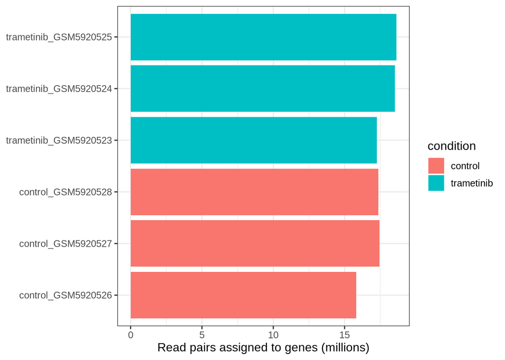

```r
tibble(sample = colnames(counts), assigned_pairs_M = colSums(counts) / 1e6) |>
  left_join(meta, by = "sample") |>
  ggplot(aes(sample, assigned_pairs_M, fill = condition)) +
  geom_col() +
  coord_flip() +
  labs(x = NULL, y = "Read pairs assigned to genes (millions)")
```

## Differential expression

```r
dds <- DESeqDataSetFromMatrix(counts[keep, ], meta, design = ~ condition)
dds <- DESeq(dds)
coef <- paste0("condition_", params$treatment, "_vs_", params$control)
res <- results(dds, name = coef, alpha = 0.05)
shrunk <- lfcShrink(dds, coef = coef, type = "apeglm")

tab <- as.data.frame(res) |>
  rownames_to_column("gene_id") |>
  mutate(
    log2FC_shrunk = shrunk$log2FoldChange,
    symbol = unname(mapIds(org.Hs.eg.db, gene_id, "SYMBOL", "ENSEMBL")),
    entrez = unname(mapIds(org.Hs.eg.db, gene_id, "ENTREZID", "ENSEMBL"))
  ) |>
  arrange(padj)

sig <- tab |> filter(padj < 0.05, abs(log2FC_shrunk) > 1)
write_tsv(tab, file.path(params$outdir, "deseq2_results.tsv"))
write_tsv(sig, file.path(params$outdir, "deseq2_significant.tsv"))

sig |> count(direction = if_else(log2FC_shrunk > 0, "up", "down"))
```

```
  direction    n
1      down 1915
2        up 1601
```

Significant: adjusted p < 0.05 and |shrunken log2 fold change| > 1.

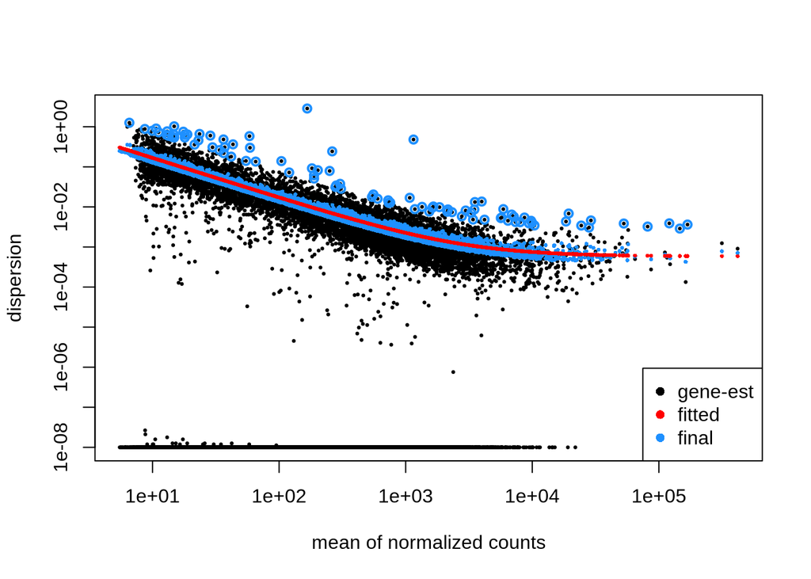

```r
plotDispEsts(dds)
```

```r
signif(dispersionFunction(dds)(c(100, 1000, 10000)), 2)
```

```
[1] 0.01700 0.00230 0.00075
```

Replicate dispersion is very low (about 0.002 at 1,000 reads; biological replicates of a cell line are usually around 0.005-0.02), so these may be technical rather than independent biological replicates. P-values are therefore likely overconfident. Downstream steps lean on effect size (shrunken fold change), pathway-level consistency and validation in patient data rather than on p-value cut-offs alone.

### Sample structure

PCA on the 500 most variable genes (DESeq2 default), variance-stabilised counts.

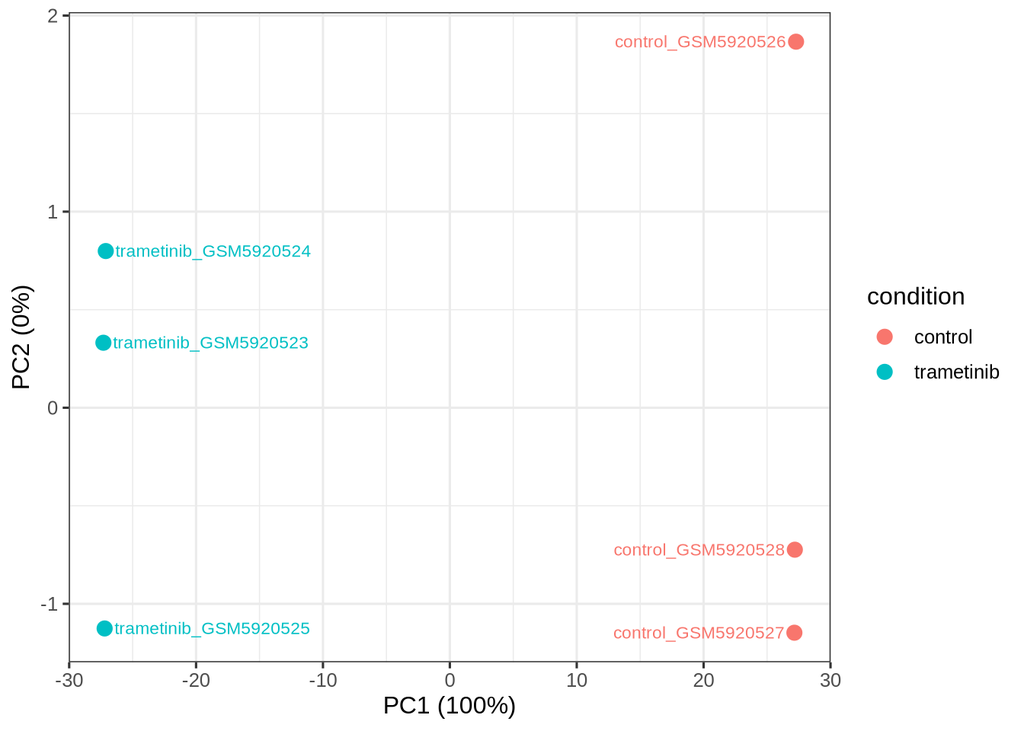

```r
vsd <- vst(dds, blind = TRUE)
pca <- plotPCA(vsd, intgroup = "condition", returnData = TRUE)
var_pct <- round(100 * attr(pca, "percentVar"))
p_pca <- ggplot(pca, aes(PC1, PC2, colour = condition, label = name)) +
  geom_point(size = 3) +
  geom_text_repel(size = 3, show.legend = FALSE) +
  labs(x = paste0("PC1 (", var_pct[1], "%)"), y = paste0("PC2 (", var_pct[2], "%)"))
ggsave(file.path(params$outdir, "figures", "pca.png"), p_pca, width = 6, height = 4.5, dpi = 150)
p_pca
```

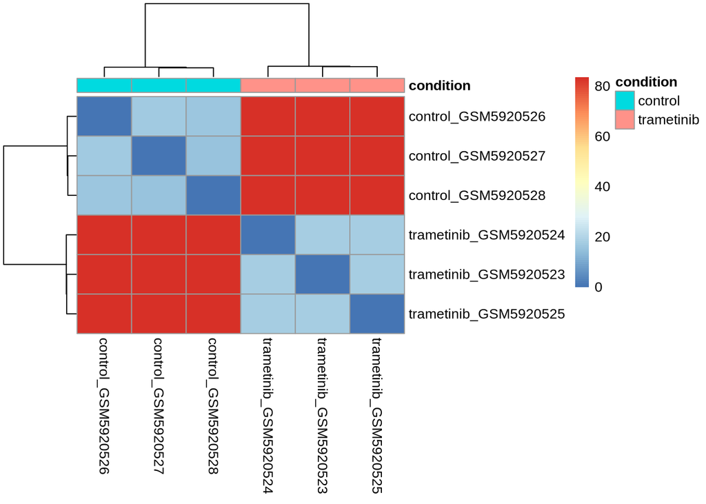

```r
d <- as.matrix(dist(t(assay(vsd))))
pheatmap(d, annotation_col = meta |> column_to_rownames("sample") |> select(condition),
         clustering_distance_rows = "euclidean", clustering_distance_cols = "euclidean")
```

### MA and volcano

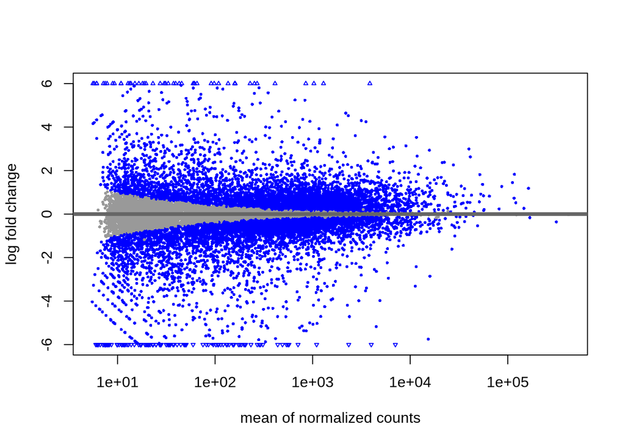

```r
plotMA(shrunk, ylim = c(-6, 6), alpha = 0.05)
```

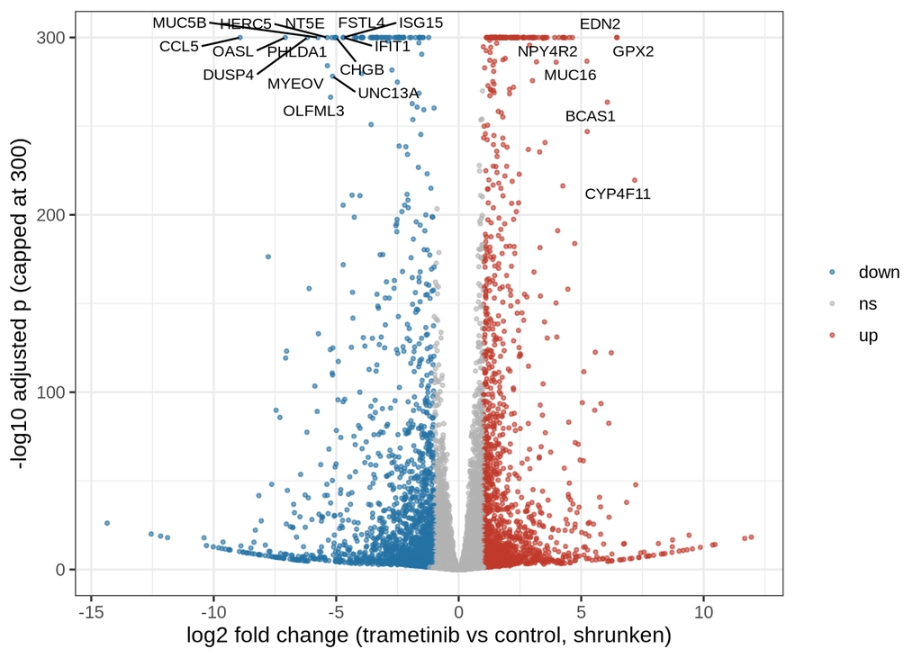

```r
# Many genes have padj that underflows to 0, so cap the y axis and label by effect size x significance
volcano_df <- tab |>
  filter(!is.na(padj)) |>
  mutate(neg_log10_padj = -log10(pmax(padj, 1e-300)),
         group = case_when(padj < 0.05 & log2FC_shrunk > 1 ~ "up",
                           padj < 0.05 & log2FC_shrunk < -1 ~ "down",
                           TRUE ~ "ns"))
labels <- volcano_df |> filter(!is.na(symbol), group != "ns") |>
  slice_max(abs(log2FC_shrunk) * neg_log10_padj, n = 20)
p_volcano <- volcano_df |>
  ggplot(aes(log2FC_shrunk, neg_log10_padj, colour = group)) +
  geom_point(size = 0.7, alpha = 0.6) +
  geom_text_repel(data = labels, aes(label = symbol), colour = "black", size = 3, max.overlaps = 30) +
  scale_colour_manual(values = c(up = "#c0392b", down = "#2471a3", ns = "grey70")) +
  labs(x = paste0("log2 fold change (", params$treatment, " vs ", params$control, ", shrunken)"), y = "-log10 adjusted p (capped at 300)", colour = NULL)
ggsave(file.path(params$outdir, "figures", "volcano.png"), p_volcano, width = 7, height = 5.5, dpi = 150)
p_volcano
```

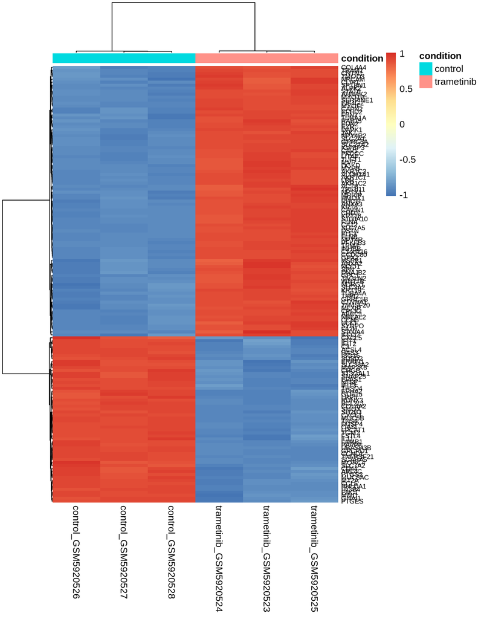

```r
top <- tab |> filter(!is.na(padj)) |> slice_min(padj, n = 50)
m <- assay(vsd)[top$gene_id, ]
rownames(m) <- coalesce(top$symbol, top$gene_id)
pheatmap(m, scale = "row", annotation_col = meta |> column_to_rownames("sample") |> select(condition),
         fontsize_row = 7)
```

## Sanity check: known MEK/ERK targets

Trametinib blocks MEK, so classic ERK-driven transcripts should fall.

```r
mek <- tab |> filter(symbol %in% c(params$markers, "MYC")) |>
  select(symbol, baseMean, log2FC_shrunk, padj) |>
  arrange(log2FC_shrunk)
mek
```

```
   symbol   baseMean log2FC_shrunk          padj
1   SPRY4  232.99988   -12.5541558  9.195119e-21
2    ETV4 1098.03027    -7.7750283 4.122242e-177
3   DUSP4 7047.43743    -6.1757079  0.000000e+00
4  PHLDA1 4476.71364    -5.1745701  0.000000e+00
5   DUSP6  134.43794    -5.1544152  5.954115e-51
6    ETV5  304.82056    -4.9161250 4.643951e-118
7   SPRY2  213.33667    -4.0910646  6.457446e-82
8    EGR1   29.26341    -3.4921770  5.575535e-13
9   CCND1 3031.65415    -2.4378892  0.000000e+00
10  FOSL1  527.67354    -1.3616723  6.724585e-55
11    MYC 1408.04828    -0.2354926  6.415711e-05
```

```r
# DUSP6 is the most robust ERK readout; if it is not down, something upstream is wrong
if (params$gate_direction != "none") {
  g <- tab |> filter(symbol == params$gate_gene)
  stopifnot(nrow(g) == 1, g$padj < 0.05,
            sign(g$log2FC_shrunk) == if (params$gate_direction == "down") -1 else 1)
}
```

## Pathway enrichment

### GSEA on MSigDB Hallmark

Genes ranked by the DESeq2 Wald statistic; one entry per gene symbol.

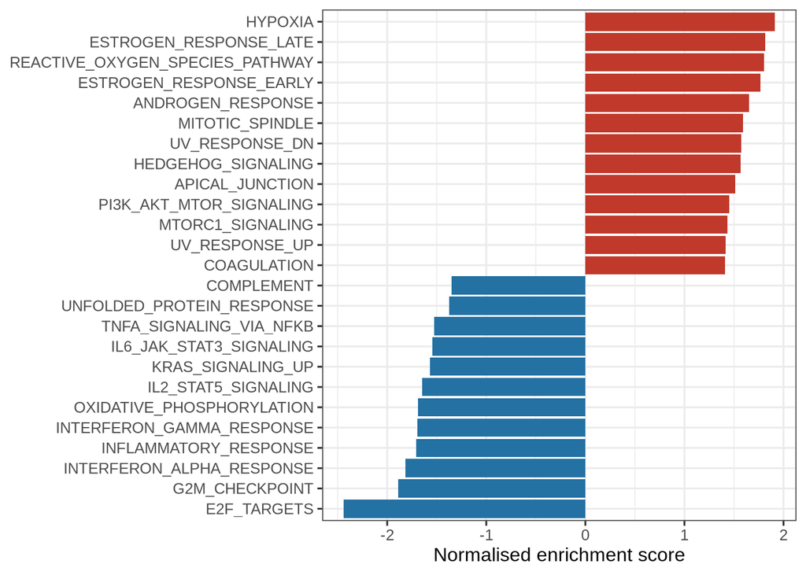

```r
ranks <- tab |>
  filter(!is.na(symbol), !is.na(stat)) |>
  group_by(symbol) |>
  slice_max(abs(stat), n = 1, with_ties = FALSE) |>
  ungroup() |>
  arrange(desc(stat)) |>
  (\(x) setNames(x$stat, x$symbol))()

hallmark <- msigdbr(species = "Homo sapiens", collection = "H")
hallmark <- split(hallmark$gene_symbol, hallmark$gs_name)

gsea <- fgsea(hallmark, ranks, minSize = 15, maxSize = 500) |> arrange(padj)
write_tsv(gsea |> mutate(leadingEdge = map_chr(leadingEdge, paste, collapse = ",")),
          file.path(params$outdir, "fgsea_hallmark.tsv"))

p_gsea <- gsea |>
  filter(padj < 0.05) |>
  mutate(pathway = fct_reorder(str_remove(pathway, "^HALLMARK_"), NES)) |>
  ggplot(aes(NES, pathway, fill = NES > 0)) +
  geom_col() +
  scale_fill_manual(values = c(`TRUE` = "#c0392b", `FALSE` = "#2471a3"), guide = "none") +
  labs(x = "Normalised enrichment score", y = NULL)
ggsave(file.path(params$outdir, "figures", "gsea_hallmark.png"), p_gsea, width = 7, height = 6, dpi = 150)
p_gsea
```

### GO biological process (over-representation)

Up- and down-regulated significant genes tested separately against all genes that passed filtering.

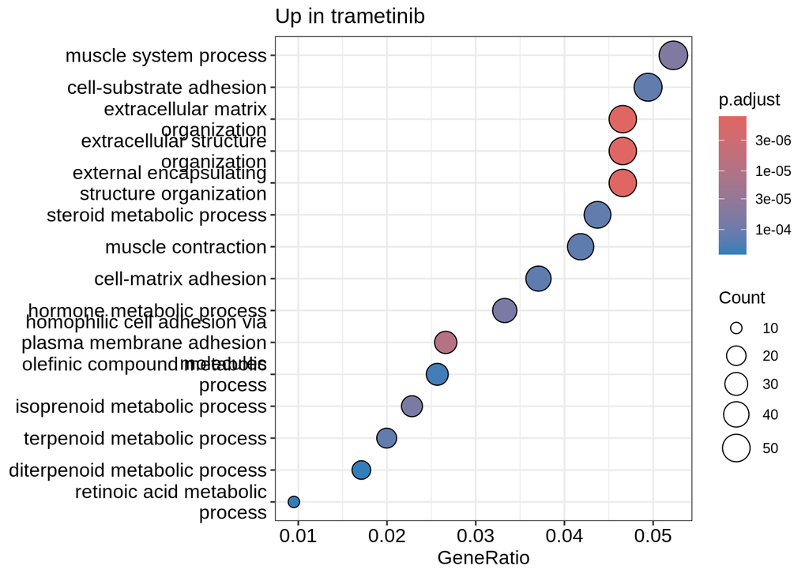

```r
go_for <- function(ids) {
  enrichGO(ids, universe = tab$gene_id, OrgDb = org.Hs.eg.db, keyType = "ENSEMBL",
           ont = "BP", readable = TRUE)
}
go_up <- go_for(sig$gene_id[sig$log2FC_shrunk > 0])
go_down <- go_for(sig$gene_id[sig$log2FC_shrunk < 0])
write_tsv(as.data.frame(go_up), file.path(params$outdir, "go_bp_up.tsv"))
write_tsv(as.data.frame(go_down), file.path(params$outdir, "go_bp_down.tsv"))
dotplot(go_up, showCategory = 15) + ggtitle(paste("Up in", params$treatment))
```

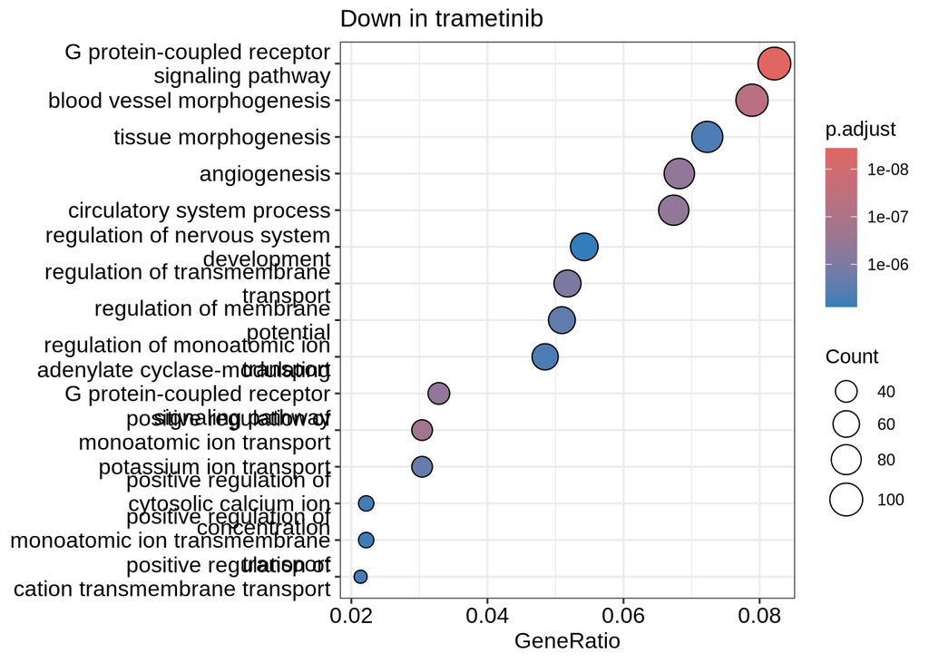

```r
dotplot(go_down, showCategory = 15) + ggtitle(paste("Down in", params$treatment))
```

### KEGG (over-representation)

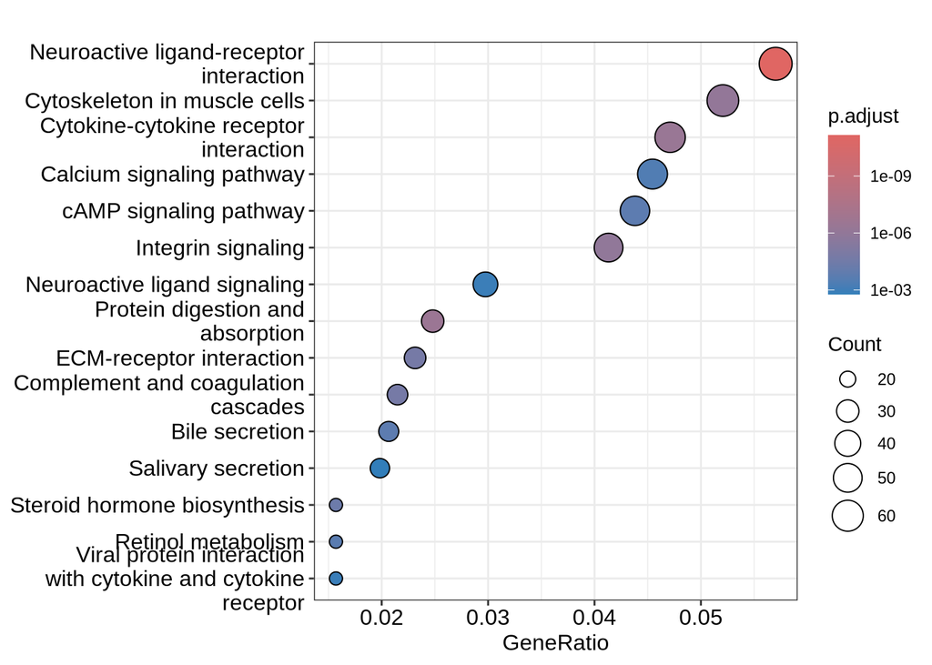

```r
# KEGG is queried online; a service outage should not sink the whole report
kegg <- tryCatch(
  enrichKEGG(na.omit(sig$entrez), universe = na.omit(tab$entrez), organism = "hsa"),
  error = function(e) {
    message("KEGG unavailable: ", conditionMessage(e))
    unlink(file.path(params$outdir, "kegg.tsv"))  # do not leave a table from an earlier run looking current
    NULL
  }
)
if (!is.null(kegg)) {
  write_tsv(as.data.frame(kegg), file.path(params$outdir, "kegg.tsv"))
  dotplot(kegg, showCategory = 15)
}
```